# Titanic

Juan Manuel Cabrera

2023-07-26

### **Análisis del dataframe Titanic**

En primer lugar se importa los datos y se muestran las 6 primeras filas.

|  | PassengerId | Survived | Pclass | Name | Sex | Age | SibSp | Parch | Ticket | Fare | Cabin | Embarked |
| --- | --- | --- | --- | --- | --- | --- | --- | --- | --- | --- | --- | --- |
| 1 | 1 | 0 | 3 | Braund, Mr. Owen Harris | male | 22 | 1 | 0 | A/5 21171 | 7.2500 |  | S |
| 2 | 2 | 1 | 1 | Cumings, Mrs. John Bradley (Florence Briggs Thayer) | female | 38 | 1 | 0 | PC 17599 | 71.2833 | C85 | C |
| 3 | 3 | 1 | 3 | Heikkinen, Miss. Laina | female | 26 | 0 | 0 | STON/O2. 3101282 | 7.9250 |  | S |
| 4 | 4 | 1 | 1 | Futrelle, Mrs. Jacques Heath (Lily May Peel) | female | 35 | 1 | 0 | 113803 | 53.1000 | C123 | S |
| 5 | 5 | 0 | 3 | Allen, Mr. William Henry | male | 35 | 0 | 0 | 373450 | 8.0500 |  | S |
| 6 | 6 | 0 | 3 | Moran, Mr. James | male | NA | 0 | 0 | 330877 | 8.4583 |  | Q |

A continuación se muestran la estructura del dataframe

```
## 'data.frame':    891 obs. of  12 variables:
##  $ PassengerId: int  1 2 3 4 5 6 7 8 9 10 ...
##  $ Survived   : int  0 1 1 1 0 0 0 0 1 1 ...
##  $ Pclass     : int  3 1 3 1 3 3 1 3 3 2 ...
##  $ Name       : chr  "Braund, Mr. Owen Harris" "Cumings, Mrs. John Bradley (Florence Briggs Thayer)" "Heikkinen, Miss. Laina" "Futrelle, Mrs. Jacques Heath (Lily May Peel)" ...
##  $ Sex        : chr  "male" "female" "female" "female" ...
##  $ Age        : num  22 38 26 35 35 NA 54 2 27 14 ...
##  $ SibSp      : int  1 1 0 1 0 0 0 3 0 1 ...
##  $ Parch      : int  0 0 0 0 0 0 0 1 2 0 ...
##  $ Ticket     : chr  "A/5 21171" "PC 17599" "STON/O2. 3101282" "113803" ...
##  $ Fare       : num  7.25 71.28 7.92 53.1 8.05 ...
##  $ Cabin      : chr  "" "C85" "" "C123" ...
##  $ Embarked   : chr  "S" "C" "S" "S" ...
```

### **Escala de las variables**

Analizando el dataframe se observan las escalas y formato de las variables:

| Variable | Escala | Formato |
| --- | --- | --- |
| PassengerId | Discreta | integer |
| Survived | Nominal | integer |
| Pclass | Ordinal | integer |
| Name | — | character |
| Sex | Nominal | character |
| Age | Discreta | numeric |
| SibSp | Discreta | integer |
| Parch | Discreta | integer |
| Ticket | Nominal | character |
| Fare | Continua | numeric |
| Cabin | Nominal | character |
| Embarked | Nominal | character |

En el dataframe del Titanic se disponen de varias variables categóricas, estas son:

- Survived: indica si el pasajero ha sobrevivido:
  - 1 Ha sobrevivido
  - 0 No ha sobrevivido
- Pclass: indica el nivel de clase:
  - 1 primera clase
  - 2 segunda clase
  - 3 tercera clase
- Sex: indica el género:
  - male (hombre)
  - female (mujer).
- SibSP: señala número de hermanos.
- Parch: indica el número de padres cuyos hijos están a bordo.
- Embarked: representa la puerta de embarcación

Todas estas variables categóricas vienen expresadas con diferentes formatos.

Siendo necesario factorizarlas con la finalidad de poder trabajar con ellas.

Factorizada las variables categóricas volvemos a comprobar el formato:

| Variable | Formato |
| --- | --- |
| Survived | factor |
| Pclass | factor |
| Sex | factor |
| SibSp | factor |
| Parch | factor |
| Embarked | factor |

Para el resto de variables no sería necesario transformarlas

## **¿Cuándas personas sobrevivieron?**

En la tragedia del titanic sobrevivieron un total de **342 personas** y perecieron un total de **549 personas**. Esto supone que sobrevivió el **38.38%** del pasaje.

## **Comparación entre pasaje que sobrevivió y edad**

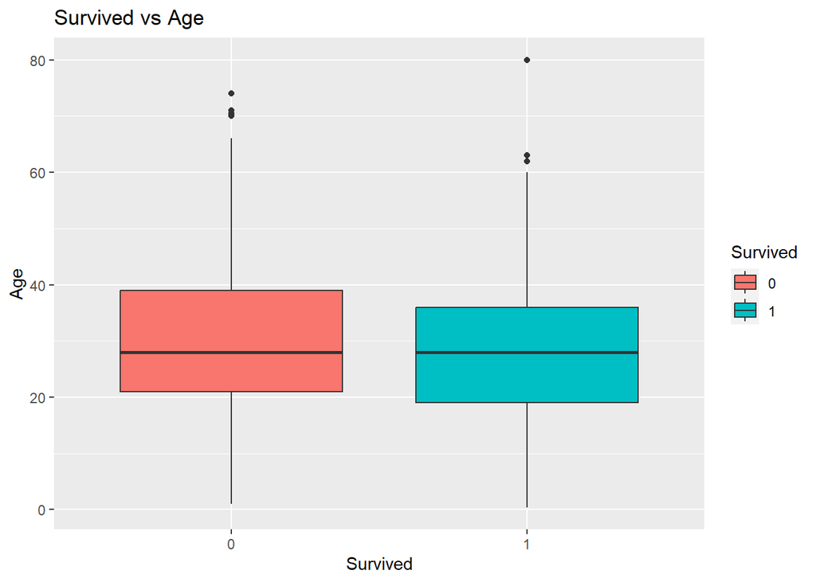

En este gráfico se ha representado mediante cajas las variables Survived y Age.

De dicho gráfico se pueden extraer las siguientes concluciones

- La edad media de personas que sobrevivieron y que no es entorno a los 28 años.
- En general sobrevivieron personas más jóvenes.

## **Comparación entre pasaje que sobrevivió y genero**

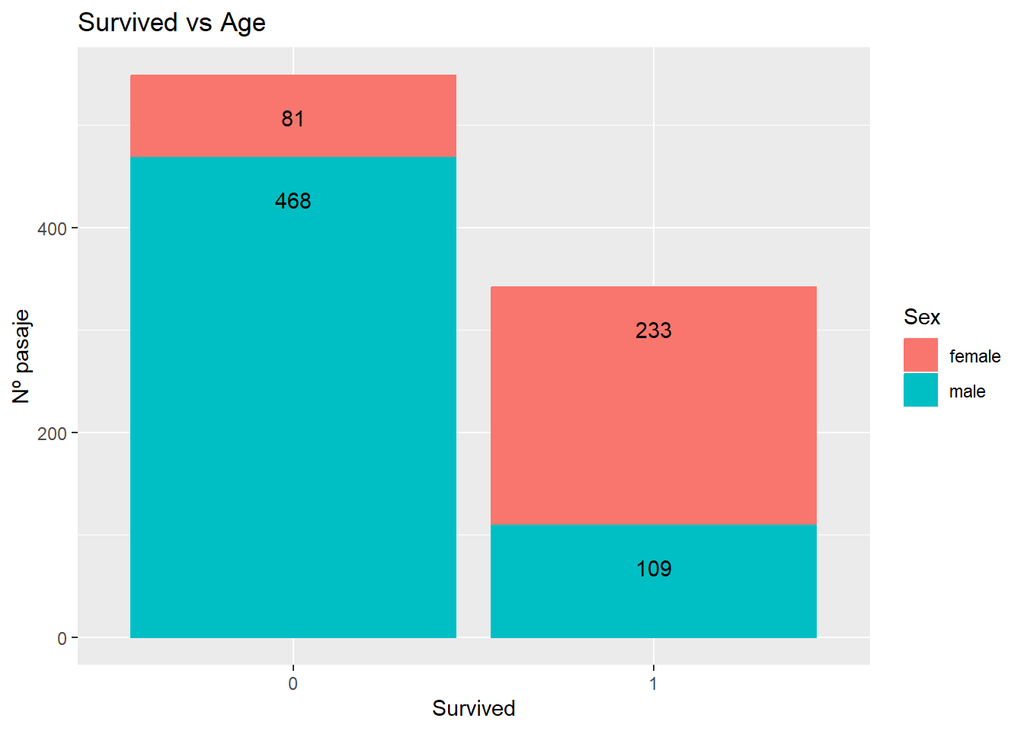

En el gráfico anterior se ha mostrado mediante un gráfico de barras el número de pasaje que sobrevivió y que falleció en función del sexo.

El número de pasaje que sobrevivó fue de 233 mujeres y 109 hombres.

Comparandola en función del número total de hombres y mujeres respectivamente, sobrevivió el 18.89% de los hombres y el 74.2% de las mujeres.

## **Comparación entre pasaje que sobrevivió y clase social**

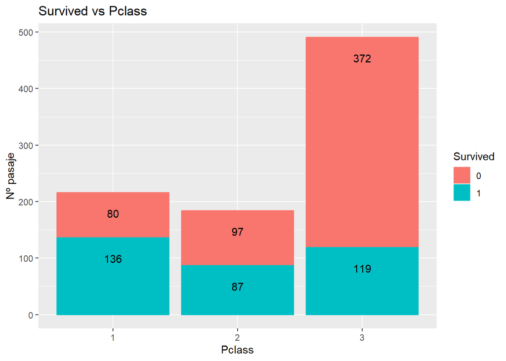

En este caso se ha mostrado el nº de pasaje que sobrevivió o no en función de la clase social.